# Der Effekt von Earnings-Conference Calls am Aktienmarkt

# Motivation

Earnings Conference Calls sind zentrale Informationsereignisse in Finanzmärkten. Hier kommuniziert das Management direkt mit Investoren und Analysten über die aktuelle Geschäftslage und Zukunftsaussichten. Die finanzwirtschaftliche Forschung zeigt, dass diese Calls erhebliche Kursbewegungen auslösen können - doch die zugrundeliegenden Mechanismen sind noch nicht vollständig verstanden.

Während traditionelle Finanztheorie von effizienten Märkten ausgeht, die alle verfügbaren Informationen sofort verarbeiten, zeigen empirische Studien, dass die Art der Kommunikation und das Sentiment der Aussagen eigenständige Erklärungskraft für Aktienkursreaktionen besitzen. Diese Erkenntnisse haben direkte praktische Relevanz: Banken nutzen Sentiment-Analysen für algorithmische Handelsstrategien, Hedge Fonds entwickeln systematische Ansätze zur Textauswertung, und Asset Manager integrieren qualitative Informationen in ihre Bewertungsmodelle.

In diesem Projekt kombinieren Sie Event Studies - eine etablierte Methode der empirischen Finanzforschung zur Messung von Informationseffekten - mit modernen Large Language Models zur systematischen Textanalyse. Sie untersuchen, ob und wie sich qualitative Aussagen des Managements in quantifizierbaren Marktreaktionen niederschlagen, und lernen dabei sowohl die methodischen Grundlagen der Kausalitätsidentifikation als auch den praktischen Umgang mit KI-gestützten Finanzanalysen kennen.

# Event-Study-Methodik und theoretische Diskussion

1. Lesen Sie das Kapitel [“Event Studies” in Huntington-Klein (2021)](https://theeffectbook.net/ch-EventStudies.html) und beantworten Sie die folgenden Fragen dazu:

Kann eine Eventstudie helfen, den kausalen Effekt eines Earnings Conference Calls auf die Aktienrendite eines Unternehmens zu identifizieren? Gehen Sie bei der Beantwortung dieser Frage insbesondere auf die nachfolgenden Punkte ein:

- Welche Art von Variation nutzt eine Eventstudie zur Identifikation des Effekts?
- Welche Voraussetzung(en) müssen erfüllt sein, damit die Eventstudie eine gültige Kausalschätzung liefert?
  - Was bedeutet das “Joint-Test Problem” in diesem Kontext?

**Kann eine Eventstudie helfen, den kausalen Effekt eines Earnings Conference Calls auf die Aktienrendite eines Unternehmens zu identifizieren?**

Ja, eine Eventstudie ist ein etabliertes Instrument, um den kausalen Effekt eines Earnings Conference Calls auf die Aktienrendite zu untersuchen, vorausgesetzt bestimmte methodische Voraussetzungen sind erfüllt.

**1. Welche Art von Variation nutzt eine Eventstudie zur Identifikation des Effekts?**

Eventstudien nutzen vor allem die *zeitliche Variation* rund um ein klar definiertes, plötzliche Ereignis. In diesem Fall ist das der Zeitpunkt des Earnings Conference Calls. Dabei wird ein kurzes Zeitfenster – das sogenannte Event-Window – festgelegt, das wenige Tage (oder sogar nur Stunden) vor und nach dem Ereignis umfasst.

Die Methode basiert darauf, die *tatsächliche Entwicklung der Aktienrendite* während dieses Event-Windows mit einer geschätzten „normalen“ oder erwarteten Rendite zu vergleichen, die aus historischen Kursdaten oder Marktmodellen abgeleitet wird. Die Differenz zwischen der realen und der erwarteten Rendite wird als *abnormale Rendite* bezeichnet und gilt als Maß für die Wirkung des Events auf den Aktienkurs.

Diese Herangehensweise nutzt die Tatsache, dass ohne das Event die Rendite dem historischen Muster folgen würde, und jede Abweichung davon potenziell durch die Informationen des Earnings Calls verursacht wird.

**2. Welche Voraussetzungen müssen erfüllt sein, damit die Eventstudie eine gültige Kausalschätzung liefert?**

Damit die Eventstudie kausal interpretiert werden kann, sind folgende Voraussetzungen zentral:

- *Keine konkurrierenden Ereignisse*: Im Event-Window dürfen keine weiteren Ereignisse auftreten, die ebenfalls Einfluss auf die Aktienrendite haben könnten. Andernfalls ist die Zuordnung der Kursbewegung zum Earnings Call nicht eindeutig möglich.
- *Korrekte Schätzung der erwarteten Rendite*: Das Modell, das die „normale“ Kursentwicklung ohne Event beschreibt, muss valide sein. Wird das Modell falsch spezifiziert, so kann die berechnete abnormale Rendite verzerrt sein, was die Interpretation erschwert.
- *Plötzliches, klar abgegrenztes Ereignis*: Der Earnings Call muss zeitlich genau bestimmbar und von kurzfristiger Wirkung sein. Nur dann lassen sich Kursreaktionen unmittelbar dem Event zuordnen.
- *Kurzes Event-Window*: Ein enger Zeitraum vor und nach dem Ereignis minimiert Verzerrungen durch andere Einflüsse und erlaubt die Annahme eines stabilen Kursverhaltens ohne Event.

**3. Was bedeutet das „Joint-Test Problem“ in diesem Kontext?**

Das Joint-Test Problem beschreibt eine methodische Herausforderung bei Eventstudien: Es wird gleichzeitig geprüft,

- ob das Ereignis einen Effekt auf die Aktienrendite hat, und
- ob das Modell zur Schätzung der erwarteten (Normal-)Rendite korrekt ist.

Eine signifikante abnormale Rendite kann sowohl auf einen tatsächlichen Effekt des Earnings Calls hinweisen als auch durch Fehler im Modell entstehen. Daraus folgt, dass eine Eventstudie keine eindeutige Unterscheidung zwischen diesen beiden Ursachen treffen kann.

Dieses Problem ist deshalb zentral, weil es die Interpretation der Ergebnisse erschwert und die Validität der Kausalaussage beeinflusst.

**Zusammenfassung**

Eventstudien bieten eine strukturierte Methode, um kurzfristige Effekte von Ereignissen wie Earnings Conference Calls auf Aktienrenditen zu analysieren, indem sie zeitliche Abweichungen von erwarteten Kursbewegungen betrachten. Voraussetzung für eine belastbare Kausalschätzung sind die Abwesenheit von anderen gleichzeitigen Ereignissen, eine korrekte Modellierung der erwarteten Rendite und ein klar definierter, kurzfristiger Ereigniszeitpunkt. Das Joint-Test Problem bleibt eine wesentliche Einschränkung, die bei der Analyse und Interpretation von Eventstudien-Ergebnissen berücksichtigt werden muss.

# Daten und Datenaufbereitung

## Finanzmarktkennzahlen

2. Sie sollten in einem ersten Schritt Finanzkennzahlen aus Datastream herunterladen. Insbesondere sollten Sie den Return Index (RI) und die Total Assets (WC02999) für alle Firmen im Euro Stoxx 600 Technology Index ( wir haben Ihnen die RIC Kürzel in der Readme bereitgestellt ) vom 01.01.2020 bis heute extrahieren.

Bitte laden Sie für den Return Index tägliche Daten herunter und für die Total Assets Quartalsdaten. Weiterhin sollten Sie den Total Return Index (RI) des Euro Stoxx 600 (RIC = .STOXX) herunterladen (auch tägliche Daten). Bitte achten Sie darauf alle Daten **in Euro** herunterzuladen.

Achten Sie darauf die RIC als eindeutige Identifikationskennung in ihren Datensatz aufzunehmen.

Das Institut für Finanzwirtschaft der Universität Ulm hat einen ausführlichen [Guide zu Datastream](https://www.uni-ulm.de/fileadmin/website_uni_ulm/allgemein/Update_Introduction_Datastream_May_2025.pdf) erstellt, der Ihnen beim Download der Daten sicherlich helfen kann.

Die Universität Ulm stellt für den Download Remote-PCs zur Verfügung, auf die Sie sich von daheim aus einloggen können. Bitte buchen Sie sich hier einen Slot um Zugriff auf diese PCs zu erhalten: https://www.uni-ulm.de/mawi/iof/lehre/proposals-for-theses/datastream-and-workspace/

Sie sollten ihre Daten in Excel herunterladen und in ihrem Projekt im Unterordner `data` abspeichern.

*Hinweis 1:* Es empfiehlt sich zwei Tabellenblätter im Excel File anzulegen, eines für die täglichen Daten und eines für die Quartalsdaten

*Hinweis 2:* Datastream ist eine Datenbank, die Kennzahlen zur Finanzlage von börsennotierten Unternehmen weltweit beinhaltet. Die Lizenzen zu Datastream an der Universität Ulm werden von der Studienkommission Wirtschaftswissenschaften und der LBBW bezahlt und die Datenbank steht allen WiWi-Studierenden frei zur Verfügung. [Nähere Informationen zu Datastream finden Sie hier](https://www.uni-ulm.de/mawi/iof/lehre/proposals-for-theses/datastream-and-workspace/) (Bitte beachten: Sie müssen im Uninetz (z.B. über VPN) eingeloggt sein um die Informationen zu sehen und um sich auf die Remote-PCs loggen zu können).

*Hinweis 3:* Bei den Total Assets müssen Sie immer das Enddatum des vorherigen Jahres nehmen für den Download, d.h. Start Date wäre 31.12.2019

3. Lesen Sie die Excel Datei, welche Sie in Aufgabe 2 erstellt haben, in R ein. Achten Sie darauf, dass diese Daten tidy und richtig formatiert sind. Joinen Sie die täglichen Daten mit den Quartalsdaten für die relevanten Firmen. Die Quartalsdaten zählen für das komplette Quartal zu dem diese hinzugemerged wurden.

Setzen Sie sich mit den Aktienkursen auseinander und beantworten folgende Fragen: - Sie wollen in Aufgabe 4 *Renditen* berechnen, warum sollten Sie Daten zum “Total Return Index” und nicht dem “Price” oder “Unadjusted Price” herunterladen? Schauen Sie sich zur Klärung dieser Frage den [Guide der Uni Ulm zu Datastream](https://www.uni-ulm.de/fileadmin/website_uni_ulm/allgemein/Update_Introduction_Datastream_May_2025.pdf) genauer an. Diesen Guide sollten sie auch für den Download der Daten heranziehen.

*Hinweis:* In dem tidy Datensatz sollten Sie eine Spalte mit dem Unternehmensidentifier (RIC), eine mit dem Datum und eine mit der Variablen (RI bzw. Total Assets) haben

Für die Berechnung von Renditen in Aufgabe 4 ist es entscheidend, dass die zugrunde liegenden Kursdaten nicht nur den reinen Preisverlauf einer Aktie abbilden, sondern auch alle Erträge berücksichtigen, die ein Investor tatsächlich erhalten hätte. Genau das leistet der sogenannte Total Return Index (RI). Im Gegensatz zum „Price“ oder „Unadjusted Price“, die lediglich den Börsenkurs ohne Dividenden oder Kapitalmaßnahmen darstellen, integriert der RI sämtliche Dividendenzahlungen sowie Aktiensplits und andere Ausschüttungen. Dadurch spiegelt er die vollständige Wertentwicklung eines Investments wider – so, als ob alle Erträge direkt reinvestiert worden wären.

Gerade bei der Analyse von Performance und der Berechnung von Renditen ist diese umfassende Sichtweise essenziell. Würde man stattdessen nur den Preis verwenden, würden wichtige Bestandteile der Gesamtrendite – wie Dividenden – ignoriert, was zu einer systematischen Unterschätzung der tatsächlichen Erträge führen würde. Der Datastream-Guide der Universität Ulm weist explizit darauf hin, dass für fundierte Analysen der Total Return Index verwendet werden sollte, insbesondere wenn es um vergleichbare und realitätsnahe Renditeberechnungen geht.

Im tidy Datensatz, der für die weitere Analyse verwendet wird, sollten daher mindestens drei zentrale Spalten enthalten sein: der Unternehmensidentifier (RIC), das Datum (date) sowie die jeweilige Variable – entweder der Total Return Index (RI) für tägliche Kursdaten oder Total Assets für die quartalsweisen Bilanzdaten. Diese Struktur ermöglicht es, die Daten korrekt zu verknüpfen und im nächsten Schritt valide Renditen zu berechnen.

## Renditen berechnen

4. In ihrem Datastream-Datensatz, welchen Sie in Aufgabe 2 bereits eingelesen und in Aufgabe 3 bearbeitet haben, sind die *Total Return Indices* (RI) der größten Unternehmen aus der Tech-Branche in Europa enthalten, sowie der *Total Return Indix* des Euro Stoxx 600. Der Euro Stoxx 600 ist ein großer, diversifizierter Aktienindex in Europa in dem die 600 größten Unternehmen gelistet sind. Sie sollten den Euro Stoxx 600 als Benchmark ( Rendite des Marktes ) für ihre betrachteten Unternehmen verwenden. Bitte berechnen Sie in dieser Aufgabe die Tagesrenditen aller Einzelunternehmen als:

$$\begin{equation}
Rendite_{i,t} = \frac{RI_{i,t} - RI_{i,t-1}}{RI_{i,t-1}}
\end{equation}$$

mit i = {jedes Einzelunternehmen im Datensatz} und t = {Tag}

und des Euro Stoxx 600 als:

$$\begin{equation}
Rendite_{m,t} = \frac{RI_{m,t} - RI_{m,t-1}}{RI_{m,t-1}}
\end{equation}$$

mit m = {Euro Stoxx 600} und t = {Tag}

Prüfen Sie auf NA in den Anfangszeilen und entfernen Sie diese.

Speichern Sie die Renditen der jeweiligen Unternehmen in einer neuen Variable `Rendite` ab und die Rendite des Euro Stoxx 600 als `Marktrendite`.

5. In Aufgabe 1 hatten Sie sich bereits mit der Event-Study Methodik beschäftigt, welche Sie im weiteren Verlauf des Projektes anwenden sollen. Ein erster Schritt ist es, sogenannte *Abnormale Renditen* zu berechnen. Dies sollten Sie in dieser Aufgabe mit dem sogenannten Market-adjusted returns model tun. Bitte ziehen Sie dafür die Rendite des Marktindex von der Rendite des einzelnen Unternehmens pro Tag ab.

$$\begin{equation}
AbnormaleRendite_t = Rendite_{i,t} - Rendite_{m,t}
\end{equation}$$

Beantworten Sie dazu folgende Frage:

- Warum ist es nötig die Marktrendite ( $Rendite_{m,t}$ ) von der Rendite der Einzelaktien abzuziehen? Nutzen Sie ihre Erkenntnisse aus Aufgabe 1 zur Beantwortung dieser Frage.

Der Hintergrund dieser Methodik liegt in der Zielsetzung einer Event-Studie: Es soll herausgefunden werden, ob ein bestimmtes Ereignis — etwa eine Fusion, Restrukturierung oder Veröffentlichung von Geschäftszahlen — einen über das allgemeine Marktniveau hinausgehenden Einfluss auf die Rendite eines Unternehmens hatte. Da jedoch Marktentwicklungen viele Aktien gleichzeitig betreffen, ist es notwendig, den Markteinfluss aus den Einzelrenditen herauszurechnen. Nur so kann isoliert beurteilt werden, ob sich eine Aktie signifikant besser oder schlechter als der Markt entwickelt hat.

Durch diese Adjustierung werden systematische Marktrisiken ausgeglichen, die alle Aktien gemeinsam beeinflussen. Es bleibt somit nur das „idiosynkratische Risiko“ sichtbar — also die spezifische Abweichung der einzelnen Aktie vom allgemeinen Marktverhalten, die auf das Ereignis zurückzuführen ist.

Mit der Differenz AbnormaleRendite_t = Rendite_{i,t} - Rendite_{m,t} wird daher die Überrendite bestimmt, die nicht durch allgemeine Marktbewegungen, sondern durch das spezifische Event erklärt werden kann. Bereits in Aufgabe 1 wurde erkannt, dass ein Event nur dann als wertrelevant gilt, wenn die beobachtete Rendite nicht ausschließlich durch marktweite Faktoren erklärbar ist. Das Market-adjusted-Modell operationalisiert diese Annahme auf elegante Weise und bildet damit die Grundlage für eine valide Event-Analyse.

## Earnings Call-Transkripte von LSEG Workspace einlesen

Die Basis für alle weiteren Analysen sind die Abnormalen Renditen der einzelner Unternehmen, die Sie in den vorherigen Aufgaben berechnet haben. Jedoch benötigen Sie nun noch ein Event, dessen Effekt Sie im Rahmen der Eventstudie analysieren möchten. Hier kommen die bereits in der Motivation erwähnten Earnings-Conference-Calls ins Spiel, die Sie im weiteren Verlauf des Projekts näher analysieren sollten. Die Earnings Conference Calls finden für große Unternehmen in der Regel quartalsweise statt. Manche Unternehmen halten jedoch auch nur halbjährliche Earnings Conference Calls ab und andere verzichten ganz darauf.

6. Wir haben Ihnen die Earnings Conference Calls aus LSEG Workspace für alle Firmen aus dem Euro Stoxx 600 Technology Sektor ab 2020 bis zum aktuellen Rand heruntergeladen und diese unter `data/transcripts.zip` bereitgestellt. Lesen Sie die Dateien in R ein. Ihr Datensatz sollte für jedes Transkript das RIC-Kürzel, Datum und den Text des Transkripts beinhalten, dies können Sie aus dem N amen der Datei extrahieren.

*Hinweis:* Das RIC Kürzel finden Sie im Namen der Datei (Beispiel: “2020-Jan-28-SAPG.DE-140242583050-Transcript.txt” -> “Datum-RIC-Nummer-Transcript.txt”)

Die Earnings Conference Calls laufen immer gleich ab: Zuerst spricht der CEO und meist CFO über die aktuellen Entwicklungen am Markt und wie das Unternehmen aktuell steht. Weiterhin werden Einschätzungen für die Zukunft angesprochen. Im zweiten Teil, der Q&A Sektion, dürfen Analysten Fragen an das Management stellen. Dieser Teil ist meist informativer als die vorbereiteten Statements des Managements, da die Fragen nicht vorher abgesprochen werden und das Management spontane Antworten bereithalten muss.

Sie sollen sich in diesem Projekt auf den zweiten Teil, d.h. die Q&A Section in den Earnings Conference Calls konzentrieren.

7. Analysieren Sie im ersten Schritt die Earnings Conference Calls indem Sie einige davon überfliegen. Schauen Sie explizit nach Hinweisen, ob und wie die Q&A Sektion im Text von den anderen Inhalten abgetrennt ist. Anschließend sollten Sie diese Q&A Sektion in den Earnings Conference Calls in R extrahieren, da Sie nur diese Sektion in den späteren Aufgaben analysieren sollen.

Da es vorteilhaft für ihre weitergehenden Analysen ist möglichst kompakte Texte ohne Redundanzen zu haben, sollten Sie zusätzlich die Definitionen und Disclaimer Sektion am Ende des Earnings Calls entfernen.

*Hinweis 1:* Der Anteil der Q&A Sektion an der Gesamtkonversation liegt in der Regel unter 80%. Für manche Earnings Conference Calls ist dieser Anteil höher, aber hier würde ich empfehlen nachzuschauen, ob Sie die Q&A Sektion richtig extrahiert haben. Manchmal gibt es keine Q&A Sektion, dann sollte dort auch kein Text extrahiert werden.

*Hinweis 2:* Nutzen Sie das Paket `stringr` um Textmanipulationen vorzunehmen. In diesem [Cheatsheet](https://rstudio.github.io/cheatsheets/strings.pdf) sehen Sie die Hauptanwendungen inkl. regulärer Ausdrücke, welche wichtig sind um mit Texten zu arbeiten.

8. Stellen Sie in einer Grafik anschaulich dar, wie viele Worte in einem typischen Earnings Conference Call verwendet werden und wie viel davon die Q&A Sektion einnimmt.

Beschreiben Sie ihre Grafik.

*Hinweis:* Eventuell wollen Sie hier die Verteilungen zeigen o.ä.? Entscheiden Sie selbst, welche Grafik Sie produzieren.

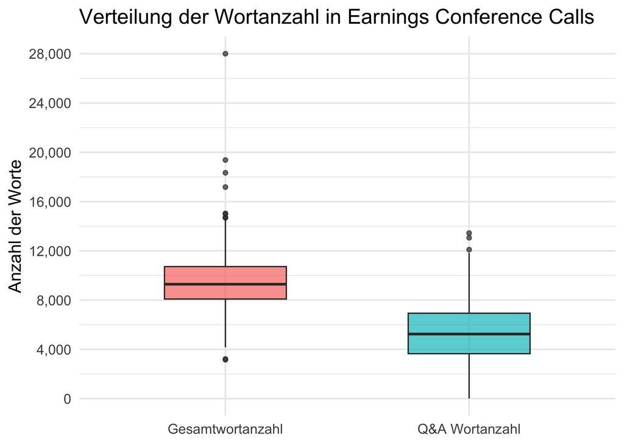

Insgesamt zeigt die Grafik, dass Earnings Calls in ihrer Struktur relativ standardisiert sind, die Q&A-Sektionen jedoch je nach Kontext (z.B. Geschäftsentwicklung, Unsicherheiten, neue Strategien) in ihrer Länge stark variieren können. Die Analyse hilft damit, ein besseres Verständnis für die Rolle der Q&A-Sektion in der Unternehmenskommunikation zu gewinnen.

## Themenkategorien und Sentiment-Scores

Nachdem Sie nun die Earnings Conference Calls in R eingelesen und einen ersten Eindruck von deren Inhalt erhalten haben sollten Sie diese mit einem LLM (konkret mit Google Gemini) analysieren. Dafür sollten Sie einen Zero-Shot Prompt erstellen und mit Hilfe dieses Prompts die Aussage der Q&A Sektionen der Earnings Conference Calls analysieren.

9. Entwickeln Sie einen Zero-Shot Prompt für ein Large Language Model (LLM), der Earnings Conference Call Transcripts analysiert und strukturierte Sentiment-Bewertungen ausgibt. Bitte beachten Sie dabei folgende Punkte:

Zielkategorien:

- Unternehmensperformance (Finanzlage, Wachstumschancen, Unternehmensrisiken)
- Marktumfeld (Branche, Wettbewerb, externe Faktoren)

Output-Format:

- JSON-Struktur mit Sentiment-Scores von -1 (sehr negativ) bis +1 (sehr positiv)
- Keine zusätzlichen Erklärungen oder Markdown-Formatierung

Sie sollten in ihrem Prompt nach einem JSON Output verlangen (strukturiertes Format), welchen Sie mit dem Paket `jsonlite` gut in R verarbeiten können.

*Hinweis 1:* Im Anhang ist eine Erklärung für die Unterschiede zwischen einem Zero-Shot Prompt, einem One-Shot Prompt und einem Few-Shot Prompt

*Hinweis 2:* Wir haben Ihnen ein [Tutorial zusammengestellt](https://projektkurs-data-science-ulm2425.netlify.app/tutorials/zero-prompting), welches das Prompting an einem Beispiel zeigt.

Analysiere das Sentiment des folgenden Q&A-Abschnitts aus einem Earnings Conference Call. Gib eine Sentiment-Bewertung für jede der beiden Kategorien: “Unternehmensperformance” und “Marktumfeld”. Der Sentiment-Score muss von -1 (sehr negativ) bis +1 (sehr positiv) reichen.

“Unternehmensperformance” umfasst die Finanzlage, Wachstumschancen und Unternehmensrisiken. “Marktumfeld” umfasst die Branche, den Wettbewerb und externe Faktoren.

Deine Ausgabe muss ein JSON-Objekt sein, ohne zusätzlichen Text oder Markdown-Formatierung. Das JSON-Objekt sollte zwei Schlüssel haben: “Unternehmensperformance” und “Marktumfeld”, mit den entsprechenden Sentiment-Scores als Werte.

Q&A-ABSCHNITT: [HIER Q&A-ABSCHNITT-TRANSKRIPT EINFÜGEN]

10. Im nächsten Schritt sollten Sie sich in das Paket [`ellmer`](https://ellmer.tidyverse.org/) einarbeiten. Durch `ellmer` erhalten Sie Zugriff auf alle gängigen LLMs mittels R über einen API Zugang. Wir haben ihnen für dieses Projekt ein Google Konto pro Gruppe erstellt und den API Schlüssel für jede Gruppe in das dazugehörige Repo (Readme) gepushed.
- Lesen Sie sich in das [`ellmer`](https://ellmer.tidyverse.org/) Paket ein und wie Sie den API Schlüssel für Google Gemini in ihrer .Renviron Datei hinterlegen können
- Untersuchen Sie die unterschiedlichen Modelle, die Google zur Verfügung stellt und deren Ratelimits: https://ai.google.dev/gemini-api/docs/models?hl=de

Bitte beantworten Sie folgende Fragen:

- Was sind die Vorteile/Nachteile der einzelnen Google Modelle?
- Welches (kostenlose) Modell würden Sie für ihre aktuellen Analysen bevorzugt einsetzen? Begründen Sie!
- Welche Möglichkeiten haben Sie, nicht in die Ratelimits zu kommen?
- In `ellmer` können Sie mittels dem [`params()`](https://www.tidyverse.org/blog/2025/05/ellmer-0-2-0/#parameters) Parameter auch die Temperatur ihres Modells einstellen. Was ist mit der Temperatur gemeint und was sind die Vorteile/Nachteile einer niedrigen Temperatur?

Das Paket ellmer bietet in R eine einfache Möglichkeit, verschiedene Large Language Models (LLMs), darunter auch Google Gemini, zu nutzen. Dabei können API-Schlüssel sicher in der .Renviron-Datei gespeichert werden, was die Handhabung und Sicherheit erleichtert. Die Google Gemini Modelle unterscheiden sich vor allem hinsichtlich ihrer Größe, Leistung und den damit verbundenen Kosten sowie Ratelimits. Kleinere Modelle sind schneller und günstiger, bieten aber eine geringere Genauigkeit, während größere Modelle präzisere Ergebnisse liefern, jedoch teurer sind und strengeren Nutzungsbeschränkungen unterliegen. Für die aktuelle Analyse ist es sinnvoll, ein kostenloses oder kostengünstiges Modell zu verwenden, das ein ausgewogenes Verhältnis zwischen Leistungsfähigkeit und Verfügbarkeit bietet, um kosteneffizient und zuverlässig arbeiten zu können. Um nicht in die Ratelimits zu geraten, können verschiedene Maßnahmen ergriffen werden, wie beispielsweise das Begrenzen der Anfragen pro Zeiteinheit (Throttling), das Zwischenspeichern (Caching) von Ergebnissen zur Vermeidung redundanter API-Aufrufe oder die Nutzung von Batch-Anfragen, falls unterstützt. Ein wichtiger Parameter in ellmer ist die Temperatur, die die Kreativität der generierten Antworten steuert. Eine niedrige Temperatur führt zu präzisen, konsistenten und eher deterministischen Antworten, was besonders bei analytischen Aufgaben wie Sentiment-Analysen von Vorteil ist. Eine höhere Temperatur erzeugt kreativere und variablere Antworten, kann aber die Genauigkeit verringern. Insgesamt ermöglicht ellmer mit den Google Gemini Modellen eine flexible und leistungsfähige Analyse von Textdaten in R, wobei die Auswahl des Modells und die richtige Parametereinstellung entscheidend für den Erfolg sind.

11. Nutzen Sie ihren in Aufgabe 9 erstellten Prompt mit dem `ellmer` Paket und ihrem Google API-Key um alle 431 Earnings Conference Call Transkripte zu analysieren. Nutzen Sie für ihre Analyse das Modell Google Gemini 2.0-flash oder Google Gemini 2.5-flash.

Speichern Sie die Ergebnisse ihrer Analyse in einem strukturierten Tibble ab. Anschließend sollten Sie den Datensatz auch unter `data/sentiment.Rds` abspeichern.

Stellen Sie ihre Ergebnisse in einer Tabelle dar und beschreiben diese kurz:

- Wie ist der Mittelwert, Standardabweichung und Median der Einschätzung bezüglich Unternehmensperformance und Marktumfeld in ihren Earnings Conference Calls?

*Hinweis 1:* Achten Sie darauf nicht bei jedem Knitten die Analyse neu zu starten, sondern setzen Sie den Chunk dieser Aufgabe auf `eval = FALSE` und lassen Sie die Analyse nur einmal durchlaufen und speichern Sie die Ergebnisse ab (und laden diese später um damit weiterarbeiten zu können)

*Hinweis 2:* Achten Sie auf ihre Ratelimits und beanspruchen Sie den API Zugriff nicht zu stark, z.B. durch den Einbau von “sleep”-Zeiten in ihrem Code

Zusammenfassung der Sentimentanalyse aller Earnings Conference Calls

| Kennzahl | Wert |
| --- | --- |
| Mittelwert Unternehmensperformance | 0.689 |
| Median Unternehmensperformance | 0.800 |
| Standardabweichung Unternehmensperformance | 0.283 |
| Mittelwert Marktumfeld | 0.398 |
| Median Marktumfeld | 0.550 |
| Standardabweichung Marktumfeld | 0.446 |

In diesem Schritt haben wir eine Sentimentanalyse der Q&A-Sektionen durchgeführt. Ziel war es, die Wahrnehmung und Einschätzung der Unternehmen durch deren Management im Rahmen der Analystenfragen zu erfassen und zwei zentrale Themenbereiche, nämlich Unternehmensperformance sowie Marktumfeld in Form von Sentiment-Scores auszuwerten. Die Analyse basiert auf einem LLM-basierten Zero-Shot-Prompting-Ansatz, bei dem jeder Q&A-Abschnitt mit Blick auf diese beiden Themenbereiche bewertet wurde. Sentiment-Score von -1 (sehr negativ) bis +1 (sehr positiv).

In der Tabelle werden zunächst die Ergebnisse zur Unternehmensperformance dargestellt. Der durchschnittliche Sentiment-Score liegt mit 0,689 im positiven Bereich, was auf eine überwiegend optimistische Einschätzung der Unternehmen hinsichtlich finanzieller Lage, Wachstumschancen und Unternehmensrisiken hinweist. Durch den Median von 0,800 wird bestätigt, dass mehr als die Hälfte der Aussagen zur Unternehmensperformance sogar noch positiver bewertet wurden. Die Aussagen über verschiedene Unternehmen hinweg scheinen tendenziell ähnlich positiv zu sein, was durch die Standardabweichung von 0,283 (moderate Streuung) gestützt wird.

Neben der Einschätzung der Unternehmensperformance wurde auch das externe Marktumfeld analysiert, um zu erfassen, wie das Management die Branchenentwicklung, den Wettbewerb und weitere externe Einflüsse bewertet. Der Mittelwert beträgt hier 0,398, was auf eine eher positive Einschätzung des äußeren Umfelds hinweist. Auffällig ist, dass der Median mit 0,550 höher als der Mittelwert ist, was auf einige deutlich negativere Ausreißer schließen lässt. Zudem ist die Standardabweichung von 0,446 anzumerken, welche deutlich höher als bei der Unternehmensperformance ist. Dies spiegelt eine größere Vielfalt in der Wahrnehmung des Marktumfelds wider, was auf branchenspezifische oder makroökonomische Unsicherheiten zurückzuführen sein könnte.

Sie haben in der vorherigen Aufgabe die Stimmung bezüglich der Kategorien Unternehmensperformance und Marktperformance in den Earnings Conference Calls bestimmt. Eine Frage wäre, ob sich diese Stimmung über die Zeit hinweg verändert hat. In der folgenden Aufgabe sollen Sie sich die durchschnittliche Stimmung in diesen zwei Kategorien für die einzelnen Jahre in ihrem Datensatz näher anschauen.

12. Erstellen Sie eine geeignete Grafik um die Stimmung *aller Earnings Conference Calls eines Jahres* zu visualisieren. Tragen Sie separat die Stimmung bezüglich Unternehmensperformance und Marktumfeld ab.

Beschreiben Sie ihre Grafik.

Interpretieren Sie diese Grafik, insbesondere im Hinblick auf die gesamtwirtschaftlichen Ereignisse der letzten fünf Jahre. Hätten Sie die Ergebnisse in dieser Art erwartet?

*Hinweis:* Sie sollten sich hier eine sinnvolle Grafik überlegen, welche die Stimmungslage über die Zeit gut darstellt.

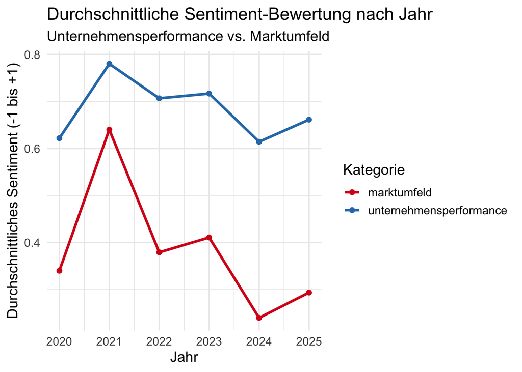

Die Entwicklung des Marktumfelds lässt sich gut durch die wirtschaftlichen Großereignisse dieser Zeit erklären. Der Anstieg im Jahr 2021 dürfte im Zusammenhang mit der wirtschaftlichen Erholung nach der COVID-19-Pandemie stehen – unterstützt durch staatliche Hilfsmaßnahmen, Impfkampagnen und die Rückkehr zu regulären Geschäftsaktivitäten. Der anschließende Rückgang ab 2022 wird begünstigt durch Faktoren wie hohe Inflation, Leitzinserhöhungen, Energiekrisen, geopolitische Spannungen und anhaltende Probleme in globalen Lieferketten. Erst 2025 deutet sich eine Entspannung an, möglicherweise durch technologische Innovationen oder eine verbesserte geopolitische Lage.

Die Unternehmensperformance zeigt sich insgesamt stabiler als das Marktumfeld. Trotz externer Schocks wie der Energiekrise, geopolitischer Unsicherheiten oder steigender Produktionskosten bleiben die Bewertungen auf einem moderaten Niveau. Dies könnte ein Hinweis darauf sein, dass Unternehmen ihre Widerstandskraft verbessert haben – etwa durch Digitalisierung, flexible Geschäftsmodelle, Effizienzsteigerung oder strategische Diversifikation.

Während die Volatilität des Marktumfelds wenig überraschend ist – makroökonomische Rahmenbedingungen reagieren grundsätzlich sensibel auf Krisen – fällt die gleichmäßige Entwicklung der Unternehmensperformance auf. Viele hätten angesichts der Unsicherheiten in den Jahren 2022 und 2023 mit deutlich stärkeren Einbrüchen gerechnet. Die beobachtete Stabilität legt nahe, dass Unternehmen heute besser vorbereitet und krisenfester agieren als noch vor einigen Jahren – ein ermutigendes Signal für Wirtschaft und Investoren.

# Eventstudie

Um zu evaluieren, ob die Earnings Conference Calls tatsächlich einen Einfluss auf die Aktienkurse der einzelnen Unternehmen hatten können Sie eine sogenannte Eventstudie durchführen, welche Sie bereits in Aufgabe 1 kennen gelernt haben. Bei einer Eventstudie betrachten Sie nur die Zeit (bei uns die Tage) unmittelbar vor oder nach einem Event. In diesem Projekt ist ein Event ein Earnings Conference Call des jeweiligen Unternehmens. Sie sollen in diesem Projekt herausfinden, wie sich über alle Unternehmen hinweg die Earnings Conference Calls auf die Aktienrenditen auswirken.

13. Verbinden Sie den Datensatz über die *Stimmung der Earnings Conference Calls (sentiment.Rds)* zu den einzelnen Unternehmen mit den *abnormalen Renditen* und speichern diesen Datensatz als `gesamtdatensatz` in R ab. Sie können das RIC-Kürzel und Datum für den Join verwenden. Sollte der Earnings Conference Call an keinem Handelstag stattgefunden haben, so joinen Sie bitte mit dem darauffolgenden Handelstag.
- Für die Tage an denen ein Earnings Conference Call stattgefunden hat sollten Sie eine Variable `event` generieren, welche an dem Tag des Calls gleich 0 ist.
- Für die Tage vor dem Earnings Conference Call (Event) sollte die Variable `event` rückwärts zählen (bis zu -5). Für alle Tage nach dem Event sollte die Variable `event` fortgeführt werden (bis +5).
- Erstellen Sie eine Variable `ar_505`, welche die *abnormalen Rendite* von Tag -5 bis +5 **fortlaufend** aufsummiert
- Erstellen Sie eine Variable `car_101`, welche die kumulierte abnormale Rendite im Zeitraum -1 bis +1 um das Event beinhaltet
- Erstellen Sie weiterhin diese sechs neuen Variablen:
  - `negativ_firm` = Wenn die Unternehmensperformance als negativ eingeschätzt wird
  - `neutral_firm` = Wenn die Unternehmensperformance als neutral eingeschätzt wird
  - `positiv_firm` = Wenn die Unternehmensperformance als positiv eingeschätzt wird
  - `negativ_market` = Wenn die Marktperformance als negativ eingeschätzt wird
  - `neutral_market` = Wenn die Marktperformance als neutral eingeschätzt wird
  - `positiv_market` = Wenn die Marktperformance als positiv eingeschätzt wird
- Erstellen Sie Dummy Variablen, die 1 sind für ein bestimmtes Jahr. Bspw. eine Dummyvariable die 2020 heißt und für alle Beobachtungen im Jahr 2020 sollte diese Variable 1 sein, 0 sonst. Tun Sie dies für alle Jahre in ihrem Datensatz

*Hinweis:* Die Funktion cumsum() könnte für diese Aufgabe hilfreich sein

14. Erstellen Sie je ein Liniendiagramm für die von ihnen betrachteten Unternehmen: Eines für die Stimmung bezüglich der Unternehmensperformance und eines bezüglich der Marktperformance.

Sie sollten in ihren Grafiken die kumulierten Renditen im Zeitraum [-5,5] Tage um einen Earnings Conference Call darstellen. - Die Variable “Event” sollte die Tage vor und nach dem Earnings Conference Call enthalten ([-5,5]) und auf der x-Achse dargestellt werden - Die Variable `ar_505` sollte die durchschnittliche kumulierte abnormale Rendite für den jeweiligen Tag auf der y-Achse abtragen (für alle Unternehmen in ihrem Datensatz) - In jeder Grafik sollten Sie eine extra Linie zeichnen für Earnings Conference Calls mit einer positiven/negativen und neutralen Stimmung und deren Einfluss auf den Aktienmarkt

Beschreiben und interpretieren Sie ihre Grafik. Gehen Sie hierbei insbesondere darauf ein, welche Erwartungen Sie auf der Basis ihrer Lektüre aus Aufgabe 1 hatten und in wie weit diese Erwartungen sich erfüllt haben.

*Hinweis:* In diesen Grafiken stellen Sie nicht jedes Event (d.h. die Auswirkungen eines jeden Earnings Conference Calls) einzeln dar, sondern gesamt für alle Earnings Conference Calls.

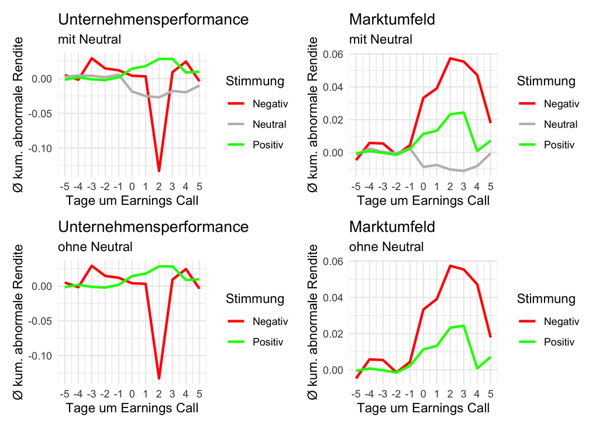

**Allgemeiner Aufbau der Grafik und Ziel der Darstellung**  
Die Grafik zeigt den durchschnittlichen Verlauf der kumulierten abnormalen Renditen (CARs) für eine Vielzahl von Earnings Conference Calls, die im Projektzeitraum stattgefunden haben. Dabei werden die Calls nicht einzeln dargestellt, sondern in drei Gruppen unterteilt – je nachdem, ob der Tonfall im Call als positiv, neutral oder negativ eingestuft wurde. Das Ziel dieser aggregierten Darstellung ist es, Muster in der Marktreaktion erkennbar zu machen und herauszufinden, ob die Tonalität eines Calls systematisch Einfluss auf die Aktienentwicklung hat.

Die vertikale Achse, also die Y-Achse, zeigt die kumulierte abnormalen Renditen in Prozent an. Ein Wert oberhalb der Nulllinie bedeutet, dass sich die Aktie in dem betrachteten Zeitraum besser entwickelt hat als der Marktindex (z.B. Euro Stoxx 600). Ein Wert unterhalb der Nulllinie zeigt eine unterdurchschnittliche Entwicklung der Aktie im Vergleich zum Markt. Je höher oder tiefer die Linie verläuft, desto stärker ist die durchschnittliche Marktreaktion auf die Tonalität des Calls.

Calls mit positivem Tonfall führen zu einem moderaten, aber sichtbaren Anstieg der CARs. Die grüne Linie verläuft oberhalb der Nulllinie und steigt meist direkt nach dem Event etwas an. Diese Entwicklung legt nahe, dass ein optimistischer Ton von Analysten und Investoren tendenziell positiv interpretiert wird, auch wenn die Kursreaktion insgesamt weniger stark ausfällt als bei negativem Ton.

Calls mit neutralem Tonfall, bei denen keine eindeutige positive oder negative Stimmung erkannt wurde, zeigen kaum Bewegung. Die Linie verläuft nahezu horizontal und bleibt in der Nähe der Nulllinie. Das bedeutet, dass der Markt auf neutrale Kommunikation kaum reagiert, was auch plausibel ist, da keine neuen Informationen oder Signale vermittelt werden.

# Regressionen

Sie haben bisher den Einfluss der Earnings Conference Calls auf die Aktienrendite der größten europäischen Unternehmen im Technologie-Sektor visuell betrachtet. Im letzten Abschnitt dieser Projektarbeit analysieren Sie ihre Daten mittels linearer Regressionen.

15. In dieser Aufgabe sollten Sie zwei Regressionen erstellen:

Regressieren Sie die kumulierten abnormalen Renditen um das Event `car_101` auf die Dummyvariablen

- `negativ_firm` und `negativ_market` in der ersten Regression und
- `positiv_firm` und `positiv_market` in der zweiten Regression.

Diese Dummyvariablen geben die Stimmung in den Earnings-Conference Calls wieder.

Beschreibung und interpretieren Sie ihre Regressionsergebnisse und gehen Sie dabei auch auf folgende Fragen ein:

- Was ist die Vergleichsgruppe in den beiden Regressionen?
- Was sind die Voraussetzungen für eine kausale Interpretation der Koeffizienten. Sind diese ihrer Meinung nach gegeben?

|  | Regressionsanalyse zur Wirkung negativer und positiver Sentiments in Earnings Calls Negative Stimmung | Regressionsanalyse zur Wirkung negativer und positiver Sentiments in Earnings Calls Positive Stimmung |
| --- | --- | --- |
| (Intercept) | 0.008+ | −0.021+ |
|  | (0.005) | (0.011) |
| negativ_firm | −0.039 |  |
|  | (0.035) |  |
| negativ_market | 0.025+ |  |
|  | (0.015) |  |
| positiv_firm |  | 0.049** |
|  |  | (0.015) |
| positiv_market |  | −0.014 |
|  |  | (0.012) |
| Num.Obs. | 402 | 402 |
| R2 | 0.008 | 0.027 |

+ p < 0.1, * p < 0.05, ** p < 0.01, *** p < 0.001

Die beiden Regressionen untersuchen, inwiefern die Stimmung in Earnings-Conference Calls die kumulierten abnormalen Renditen (car_101) beeinflusst. In der ersten Regression werden die Dummyvariablen negativ_firm und negativ_market verwendet. Das Ergebnis zeigt, dass eine negative Stimmung auf Unternehmensebene (negativ_firm) keinen signifikanten Effekt auf die Renditen hat. Dagegen ist die Variable negativ_market signifikant positiv – das heißt, wenn der Ton auf Marktebene in den Calls negativ ist, steigen die abnormalen Renditen im Schnitt. Dieses Ergebnis könnte auf eine konträre Marktreaktion oder bereits eingepreistes negatives Sentiment hindeuten, das durch den Call bestätigt wird.

Die Vergleichsgruppe in beiden Analysen besteht aus jenen Calls, die weder durch eine positive noch durch eine negative Stimmung auf Unternehmens- oder Marktebene geprägt sind, also neutralen Calls. Die angegebenen Effekte sind demnach im Vergleich zu dieser neutralen Referenzgruppe zu interpretieren.

Für eine kausale Interpretation der Ergebnisse müssten jedoch bestimmte Bedingungen erfüllt sein, die in der vorliegenden Analyse noch nicht gegeben sind. Eine zentrale Voraussetzung ist, dass keine wichtigen Einflussgrößen ausgelassen wurden, die sowohl die Stimmung im Call als auch die Renditen beeinflussen könnten – etwa der Überraschungseffekt der Quartalszahlen, makroökonomische Faktoren oder unternehmensspezifische Charakteristika wie Größe oder Branche. Solche fehlenden Variablen können die Ergebnisse verzerren (omitted variable bias). Ein weiteres Problem stellt die potenzielle Endogenität dar: Es ist denkbar, dass die erwartete Performance des Unternehmens bereits die Stimmung im Call beeinflusst, sodass sich Ursache und Wirkung gegenseitig überlagern. Auch fehlt eine zufällige Zuweisung der Stimmungsvariablen, also eine Exogenität, was bedeutet, dass Unternehmen den Ton ihrer Kommunikation gezielt und möglicherweise in Abhängigkeit von schwer messbaren Faktoren wählen. Des weiteren basiert die Analyse nicht auf einem experimentellen oder quasi-experimentellen Design, das helfen könnte, systematische Verzerrungen zu kontrollieren.

Zusammenfassend ist deshalb festzuhalten. dass die berichteten Zusammenhänge zwar interessant und ökonomisch plausibel sind, sie sollten jedoch als deskriptiv verstanden werden und nicht als Beleg für kausale Wirkzusammenhänge.

16. In ihrer deskriptiven Analyse haben Sie bereits gesehen, dass die Unternehmen, die Sie in diesem Projekt betrachten, alle unterschiedlich groß sind. Weiterhin haben Sie gesehen, dass es ein unterschiedliches Stimmungsbild in den Calls über die einzelnen Jahre hinweg gibt. Dafür möchten Sie in ihren Regressionen nun kontrollieren.
    1. Regressieren Sie die `car_101` auf die Variablen *negativ_firm* und *negativ_market* und kontrollieren Sie auf die Größe des jeweiligen Unternehmens, indem Sie die Variable *Total_Assets* in ihre Regression aufnehmen
    2. Fügen Sie in einer zweiten Analyse zusätzlich zu den Variablen aus der 1. Regression auch noch Dummyvariablen für die Jahre in dem das Event stattgefunden hat ihrer Regression hinzu.
    3. Führen Sie die Regressionen aus 1. und 2. auch für die Variablen *positiv_firm* und *positiv_market* anstatt *negativ_firm* und *negativ_market* durch, sodass Sie am Ende 4 Regressionen haben

Beschreiben und interpretieren Sie ihre Ergebnisse im Hinblick auf die Größe der Koeffizienten und deren Signifikanz. Gehen Sie insbesondere auf folgende Fragen ein:

- Warum sollte ihre Regression nicht fünf Dummyvariablen, je eine für jedes Jahr, sondern nur vier beinhalten?
- Verändert sich durch die Dummyvariablen der Koeffizient von *negativ_firm* und *negativ_market* bzw. *positiv_firm* und *positiv_market*?
- Hätten Sie eine Veränderung des Koeffizienten von *negativ_firm*, *negativ_market*, *positiv_firm* oder *positiv_market* erwartet? Begründen Sie ihre Antwort mit ihren deskriptiven Analysen.

|  | Regressionsanalyse zur Wirkung negativer und positiver Sentiments unter Kontrolle von Unternehmensgröße und Jahresdummies Neg. Stimmung + Größe | Regressionsanalyse zur Wirkung negativer und positiver Sentiments unter Kontrolle von Unternehmensgröße und Jahresdummies Neg. Stimmung + Größe + Jahr | Regressionsanalyse zur Wirkung negativer und positiver Sentiments unter Kontrolle von Unternehmensgröße und Jahresdummies Pos. Stimmung + Größe | Regressionsanalyse zur Wirkung negativer und positiver Sentiments unter Kontrolle von Unternehmensgröße und Jahresdummies Pos. Stimmung + Größe + Jahr |
| --- | --- | --- | --- | --- |
| (Intercept) | 0.011+ | 0.014 | −0.020+ | −0.014 |
|  | (0.006) | (0.011) | (0.012) | (0.015) |
| negativ_firm | −0.030 | −0.023 |  |  |
|  | (0.036) | (0.036) |  |  |
| negativ_market | 0.010 | 0.011 |  |  |
|  | (0.015) | (0.015) |  |  |
| TotalAssets | −0.000 | −0.000 | −0.000 | −0.000 |
|  | (0.000) | (0.000) | (0.000) | (0.000) |
| year_2021 |  | −0.004 |  | −0.010 |
|  |  | (0.015) |  | (0.015) |
| year_2022 |  | 0.005 |  | 0.003 |
|  |  | (0.015) |  | (0.015) |
| year_2023 |  | 0.001 |  | −0.004 |
|  |  | (0.015) |  | (0.015) |
| year_2024 |  | −0.023 |  | −0.024 |
|  |  | (0.015) |  | (0.015) |
| year_2025 |  | 0.055 |  | 0.042 |
|  |  | (0.089) |  | (0.089) |
| positiv_firm |  |  | 0.042** | 0.041** |
|  |  |  | (0.016) | (0.016) |
| positiv_market |  |  | −0.008 | −0.007 |
|  |  |  | (0.012) | (0.012) |
| Num.Obs. | 367 | 367 | 367 | 367 |
| R2 | 0.004 | 0.018 | 0.025 | 0.038 |

+ p < 0.1, * p < 0.05, ** p < 0.01, *** p < 0.001

Die vorliegende Analyse untersucht, inwiefern die Stimmung in Earnings-Conference Calls Einfluss auf die kumulierten abnormalen Renditen (car_101) von Unternehmen hat. Im Zentrum stehen dabei Dummyvariablen, die eine negative bzw. positive Tonalität auf Unternehmens- (_firm) und Marktebene (_market) kennzeichnen.

Die Vergleichsgruppe in beiden Fällen besteht aus Earnings Calls mit neutraler Tonalität, also Calls ohne erkennbare positive oder negative Stimmung. Die geschätzten Effekte der Dummyvariablen sind daher relativ zu dieser neutralen Referenz zu interpretieren. Für eine kausale Interpretation müssten wichtige Bedingungen erfüllt sein. Zunächst dürfen keine relevanten Einflussgrößen wie zum Beispiel der Überraschungseffekt der Ergebnisse oder makroökonomische Faktoren ausgelassen werden. Auch ist problematisch, dass der Ton eines Calls durch antizipierte Performance beeinflusst sein könnte, ein klassischer Fall von Endogenität. Da außerdem keine zufällige Zuweisung von Stimmung erfolgt und kein experimentelles Design vorliegt, sind unbeobachtete Verzerrungen wahrscheinlich. Entsprechend sollten die beobachteten Zusammenhänge als deskriptiv und nicht kausal gewertet werden.

17. Zum Abschluss sollten Sie dazu Stellung beziehen, in wie weit die Erkenntnisse aus diesem Projekt für eine Handelsstrategie genutzt werden könnten. Konkret sollten Sie erläutern ob es sinnvoll ist eine Unternehmensaktie bei einem negativem Sentiment im Earnings Conference Call automatisiert zu verkaufen.

Beziehen Sie sich in ihrer Argumentation insbesondere auf:

- Zeitliche Aspekte (Wann reagiert der Markt vs. wann liegt das Sentiment vor?)
- Methodische Limitationen Ihrer Event Study
- Unsicherheiten bei der LLM-Sentiment-Analyse

Begründen Sie jeden Kritikpunkt konkret mit Bezug auf Ihre Projektarbeit und schließen Sie mit einer realistischen Einschätzung ab: Wofür könnten Ihre Ergebnisse trotz dieser Limitationen in der Praxis dennoch wertvoll sein?

Basierend auf den im Projekt gewonnenen Erkenntnissen ist es nicht ratsam, bei einem negativen Sentiment im Earnings Conference Call automatisch eine Unternehmensaktie zu verkaufen. Dafür sprechen mehrere Aspekte, insbesondere im Hinblick auf Zeitverzögerung, methodische Grenzen und die Unsicherheit bei der LLM-gestützten Sentimentanalyse.

Aus zeitlicher Perspektive stellt sich das Hauptproblem darin dar, dass Earnings Calls in der Regel live stattfinden, während die entsprechenden Transkripte – insbesondere die Q&A-Sektion – oft erst Stunden später vollständig veröffentlicht werden. Somit kann der Markt bereits auf zentrale Aussagen reagiert haben, bevor das Sentiment mithilfe eines Large Language Models (LLM) analysiert werden kann. Eine automatisierte Handelsentscheidung würde daher in vielen Fällen zu spät erfolgen, um vom eigentlichen Marktimpuls zu profitieren oder sich vor Verlusten zu schützen.

Ein weiterer wesentlicher Unsicherheitsfaktor betrifft die Sentimentanalyse selbst. Auch wenn LLMs beeindruckende Leistungen in der Sprachverarbeitung liefern, bleibt die Interpretation der Unternehmenssprache im Q&A-Bereich anspruchsvoll. Fragen sind häufig mehrdeutig formuliert, Antworten diplomatisch oder strategisch vage. Solche Nuancen lassen sich nicht immer korrekt als „positiv“ oder „negativ“ klassifizieren. Das kann insbesondere bei knappen oder gemischten Aussagen zu einer verzerrten Bewertung führen. Darüber hinaus zeigt unsere Analyse, dass das Sentiment über die Jahre variiert und stark unternehmensspezifisch ist – pauschale Handelsregeln sind daher problematisch.

Trotz dieser Einschränkungen bietet die Projektarbeit wertvolle Einblicke. Insbesondere lassen sich Earnings Calls mit auffälligem Sentimentverlauf identifizieren, was für qualitative Analysen oder als Vorfilter in Research-Prozessen dienlich sein kann. Denkbar wäre etwa ein halbautomatisches Frühwarnsystem, das Analyst:innen gezielt auf potenziell kritische oder besonders optimistische Calls aufmerksam macht.

Zusammenfassend lässt sich festhalten: Eine automatisierte Verkaufsstrategie allein auf Basis negativem Sentiments im Earnings Call ist zum jetzigen Stand weder zeitlich noch analytisch verlässlich. Die Kombination aus LLM-Sentimentanalyse und Event-Study liefert jedoch hilfreiche Kontextinformationen für fundierte Anlageentscheidungen im Rahmen eines übergreifenden Research- oder Portfolioüberwachungsprozesses.

# Zusatzaufgabe

In Aufgabe 6 berechnen Sie die *abnormalen Renditen* der einzelnen von ihnen betrachteten Unternehmen. Nun könnte es allerdings sein, dass es nicht ausreicht den Marktindex einfach von der Aktienrendite abzuziehen um für die erwartete Performance der Aktie zu kontrollieren. Potentiell wäre es besser für die durchschnittliche Performance der Aktie zu kontrollieren in der keine Events stattfinden.

Sie können eine solche durchschnittliche Performance schätzen. Dazu sollten Sie eine Schätzperiode *vor* dem Event definieren. Diese Periode sollen Sie auf 120 bis 10 Handelstage vor dem Event festlegen. Die durchschnittliche Rendite der Einzelaktie sollten Sie in dieser Periode auf die Marktrendite regressieren. Dieses Modell wird `Risk-adjusted returns model` in Huntington-Klein (2021) genannt:

$$\begin{equation}
\hat{Rendite}_{i,t} = \alpha + \beta Rendite_{m,t}
\end{equation}$$

Anschließend nutzen Sie die vorhergesagten Werte und ziehen diese in der Eventphase von der Rendite der Einzelaktie ab.

18. Erstellen Sie die kumulierten abnormalen Renditen im Zeitraum -5 bis +5 mit Hilfe ihres Risk-adjusted returns model neu (und nennen diese `mar_505`). Erstellen Sie die kumulierten abnormalen Renditen im Zeitraum -1 bis +1 um das Event mit Hilfe ihres Risk-adjusted returns model neu (und nennen die Variable `cmar_101`) und vergleichen die Werte in einer geeigneten Grafik mit den Ergebnissen aus dem market-adjusted returns model (`car_101`).
- Gibt es hier große Unterschiede?
- Warum gibt es diese Unterschiede, oder warum sehen Sie nur geringe Unterschiede?

[figure not shown]

Beim Vergleich der kumulierten abnormalen Renditen aus dem Market-Adjusted Returns Model (car_101) und dem Risk-Adjusted Returns Model (cmar_101 und mar_505) zeigen sich deutliche Unterschiede. Das Market-Adjusted-Modell weist eine breite Streuung der Renditen auf, einschließlich einiger Ausreißer im positiven und negativen Bereich. Im Gegensatz dazu liefert das Risk-Adjusted-Modell (cmar_101) nahezu konstante Werte, die alle bei null zu liegen scheinen. Auch für mar_505 sind keine nennenswerten Abweichungen zu erkennen.

Diese Unterschiede lassen sich methodisch erklären, das Market-Adjusted-Modell geht davon aus, dass die erwartete Rendite der Aktie identisch mit der Rendite des Gesamtmarkts ist. Dadurch werden aktienspezifische Risikostrukturen nicht berücksichtigt, was zu einer höheren Streuung der berechneten abnormalen Renditen führen kann. Das Risk-Adjusted-Modell hingegen basiert auf einer Regressionsanalyse innerhalb einer vorher definierten Schätzperiode. Dadurch soll die erwartete Rendite jeder Aktie individuell, abhängig von ihrer historischen Sensitivität gegenüber dem Markt, geschätzt werden.

Die geringere Streuung der abnormalen Renditen im Risk-Adjusted-Modell lässt sich dadurch erklären, dass die vorhergesagten Renditen besser an die tatsächliche Entwicklung der einzelnen Aktien angepasst sind. Besonders für Unternehmen, deren Kursentwicklung stark mit dem Markt korreliert, liefert das Modell erwartete Renditen, die nahe an den realisierten Renditen im Eventzeitraum liegen. Dadurch fällt die Differenz – und somit die abnormale Rendite – geringer aus.

19. Erstellen Sie die Grafik von Aufgabe 12 neu.

Beschreiben und interpretieren Sie ihre Grafik. Gehen Sie auch auf folgende Fragen ein:

- Könnte es zu Problemen führen, wenn in der Schätzperiode vor dem Event ein weiterer Earnings-Conference Call enthalten ist?
  - Warum könnte dies ein Problem sein, oder warum nicht?

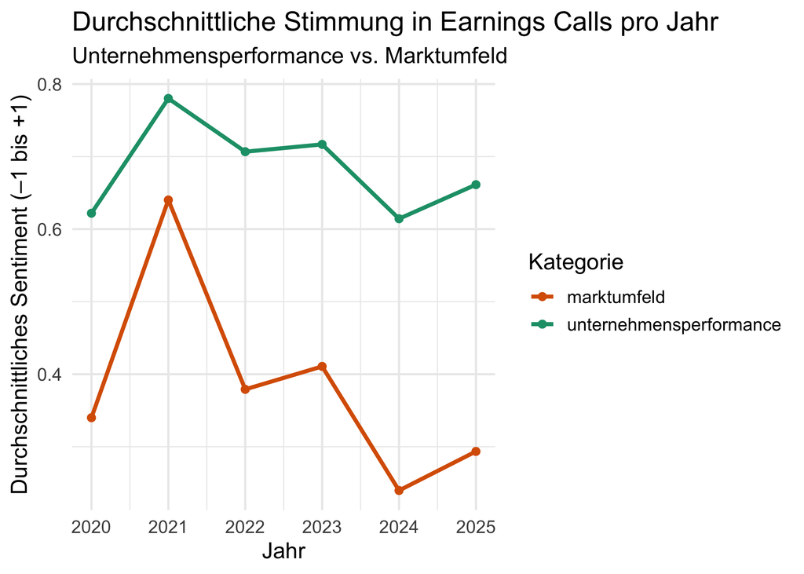

Die Grafik zeigt die Entwicklung des durchschnittlichen Sentiments in Earnings Calls der Unternehmen von 2020 bis 2025. Dabei wird zwischen Aussagen zur Unternehmensperformance und zum allgemeinen Marktumfeld unterschieden. Über den gesamten Zeitraum hinweg ist erkennbar, dass Unternehmen ihre eigene Lage positiver darstellen als das gesamtwirtschaftliche Umfeld. Besonders deutlich wird dies im Jahr 2021, in dem beide Kategorien ihren Höchststand erreichen. Die Aussagen zur Unternehmensperformance sind mit einem durchschnittlichen Sentimentwert von etwa 0,76 am optimistischsten, gefolgt vom Marktumfeld mit rund 0,64. Ab 2022 ist ein Rückgang in beiden Kategorien erkennbar, wobei das Sentiment zum Marktumfeld deutlich stärker abnimmt und 2024 einen Tiefpunkt erreicht. Diese Entwicklung könnte auf externe Belastungen wie makroökonomische Unsicherheiten, geopolitische Spannungen oder steigende Zinsen zurückzuführen sein. Im Jahr 2025 zeigt sich beim Marktumfeld eine leichte Erholung, während die Einschätzung zur Unternehmensperformance relativ stabil und auf hohem Niveau bleibt. Die Diskrepanz zwischen positiver Selbsteinschätzung und eher zurückhaltender Bewertung des Marktumfelds lässt sich als strategischer Versuch interpretieren, Vertrauen zu bewahren und Unsicherheiten zu relativieren.

Ein methodischer Aspekt, der bei der Auswertung berücksichtigt werden muss, ist die Zusammensetzung der Schätzperiode im Rahmen der Event-Studie. Sollte sich in der Schätzperiode ein weiterer Earnings-Conference Call befinden, kann dies die Ergebnisse beeinflussen. Die Schätzperiode dient dazu, ein erwartetes, unbeeinflusstes Renditemuster zu modellieren. Enthält sie jedoch ein Ereignis mit potenziell marktbewegenden Informationen, wie ein früherer Earnings Call, besteht die Gefahr, dass bereits dort Reaktionen am Kapitalmarkt ausgelöst wurden. Das kann dazu führen, dass die geschätzten normalen Renditen verzerrt sind und damit auch die daraus abgeleiteten abnormalen Renditen. Zudem könnten Kapitalmarktreaktionen auf den vorangegangenen Call vorgezogen worden sein, wodurch sich die Wirkung des eigentlichen Events im Eventfenster nur abgeschwächt zeigt. Um valide Ergebnisse zu gewährleisten, sollte die Schätzperiode deshalb möglichst frei von unternehmensspezifischen Ereignissen bleiben, die potenziell relevante Informationen enthalten.

20. Lesen Sie das Kapitel [“Fixed Effects” in Huntington-Klein (2021)](https://theeffectbook.net/ch-FixedEffects.html#how-does-it-work), speziell Kapitel 16.1
21. Regressieren Sie die `cmar_101` auf die Variablen *negativ_firm* und *negativ_market* und kontrollieren Sie auf die Größe des jeweiligen Unternehmens, indem Sie die Variable *Total_Assets* in ihre Regression aufnehmen. Kontrollieren Sie weiterhin auf das Jahr in dem das Event stattgefunden hat. Fügen Sie weiterhin der Regression Firmen-Fixe Effekte hinzu.

Beschreiben und interpretieren Sie ihre Ergebnisse.

Gehen Sie zusätzlich auf die folgenden Frage ein:

- Was sind Firmen-Fixe Effekte und warum könnten diese für ihre Regression sinnvoll sein?

*Hinweis:* Mit dem [Paket `fixest`](https://cran.r-project.org/web/packages/fixest/vignettes/fixest_walkthrough.html) und der Funktion feols() können Sie einfach ihren Regressionen fixe Effekte hinzufügen

# Literatur

- Kapitel Event Studies im Buch [The Effect Book: Event Studies](https://theeffectbook.net/ch-EventStudies.html)
- Kapitel Fixe Effekte im Buch [The Effect Book: Event Studies](https://theeffectbook.net/ch-FixedEffects.html)
- [Paket `fixest`](https://cran.r-project.org/web/packages/fixest/vignettes/fixest_walkthrough.html)

# Anhang

## Prompt Arten

Prompt-Arten unterscheiden sich in der Anzahl der Beispiele, die Sie dem KI-Modell geben:

**Zero-Shot Prompt**

- Keine Beispiele gegeben
- Nur die Aufgabe wird beschrieben
- Beispiel: “Übersetze ins Englische: Guten Morgen”

**One-Shot Prompt**

- Ein einziges Beispiel wird gezeigt
- Das Modell lernt aus diesem einen Beispiel
- Beispiel: “Übersetze ins Englische:

Guten Tag → Good day Guten Morgen → ?”

**Few-Shot Prompt**

- Mehrere Beispiele werden gegeben (typisch 2-5)
- Das Modell kann aus mehreren Mustern lernen
- Beispiel: “Übersetze ins Englische:

Guten Tag → Good day Auf Wiedersehen → Goodbye Danke → Thank you Guten Morgen → ?”